# DATA605: Discussion Post Week 12

Andrew Bowen

2023-04-19

# Multiple Regression

We can use the `Seatbelts` dataset built into R. First, we can set it up as a dataframe in R

```r
# Load the dataset into a dataframe
df <- as.data.frame(Seatbelts)
```

We can use the `law` variable as our dichotomous value, as this takes a value of 0 or 1, depending on if the seatbelt law was in effect that month. We want to predict the value of `DriversKilled`, which will be our *dependent variable*. We can use the `front` variable as our quadratice term, and the `kms` (distance driven) as our quantitative term

```r
# set up the number of front-seat passengers killed as our quantitative term
df$front2 <- df$front ** 2
```

Now, we can create our linear model

```r
mlm <- lm(DriversKilled ~ front2 + kms + law, df)

summary(mlm)
```

```
##
## Call:
## lm(formula = DriversKilled ~ front2 + kms + law, data = df)
##
## Residuals:
##     Min      1Q  Median      3Q     Max
## -44.748 -12.231  -1.382  13.969  41.662
##
## Coefficients:
##               Estimate Std. Error t value Pr(>|t|)
## (Intercept)  9.260e+01  8.944e+00  10.353   <2e-16 ***
## front2       6.050e-05  5.058e-06  11.963   <2e-16 ***
## kms         -9.865e-04  5.095e-04  -1.936   0.0544 .
## law          6.193e+00  4.969e+00   1.246   0.2142
## ---
## Signif. codes:  0 '***' 0.001 '**' 0.01 '*' 0.05 '.' 0.1 ' ' 1
##
## Residual standard error: 17.86 on 188 degrees of freedom
## Multiple R-squared:  0.5126, Adjusted R-squared:  0.5048
## F-statistic: 65.91 on 3 and 188 DF,  p-value: < 2.2e-16
```

Our F-statistic compares our model to a model with no independent variables. Since our p-value for this F-statistic is less than the typical significance level ($\alpha=0.05$), we can accept the alternative hypothesis that our model outperforms a model with no independent variables

### Testing our Regression Assumptions

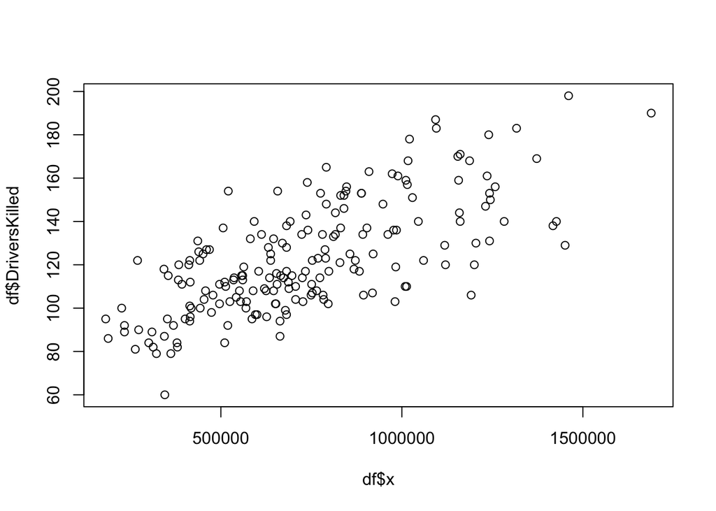

```r
# Plotting our variables to see if there's a general linear relationship
df$x <- df$front2 + df$law + df$front

plot(df$x, df$DriversKilled)
```

The above plot looks to show a general linear relationship between our dependent variable (`DriversKilled`) and our independent variables

We can use the `plot.lm` function to plot the needed graphs for testing our regression assumptions.

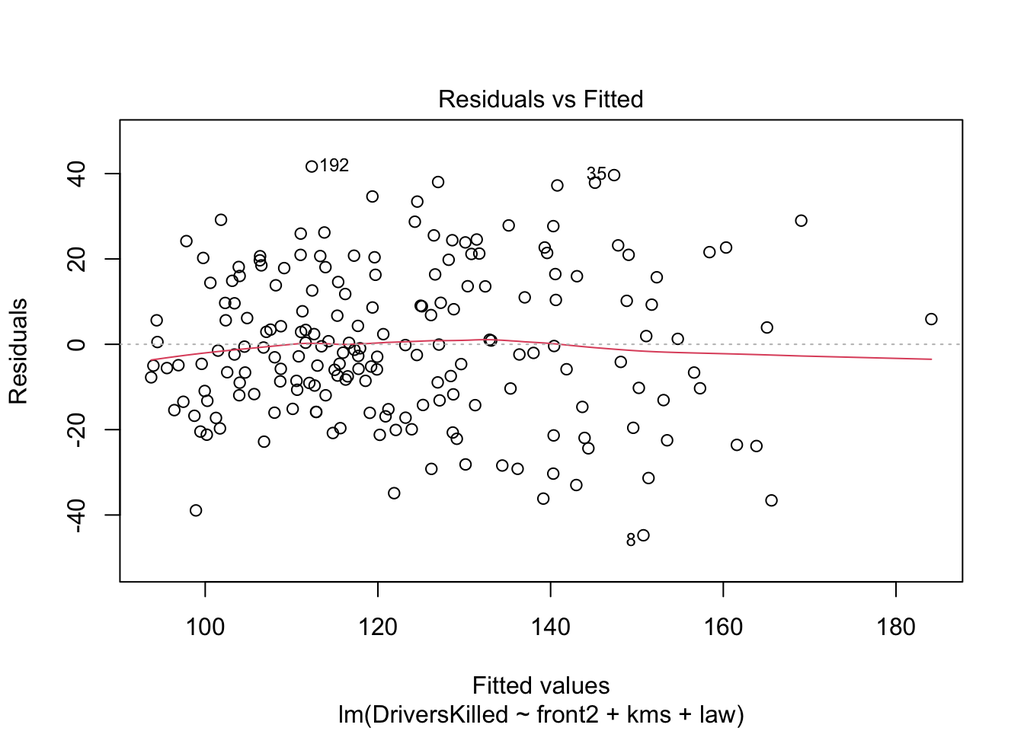

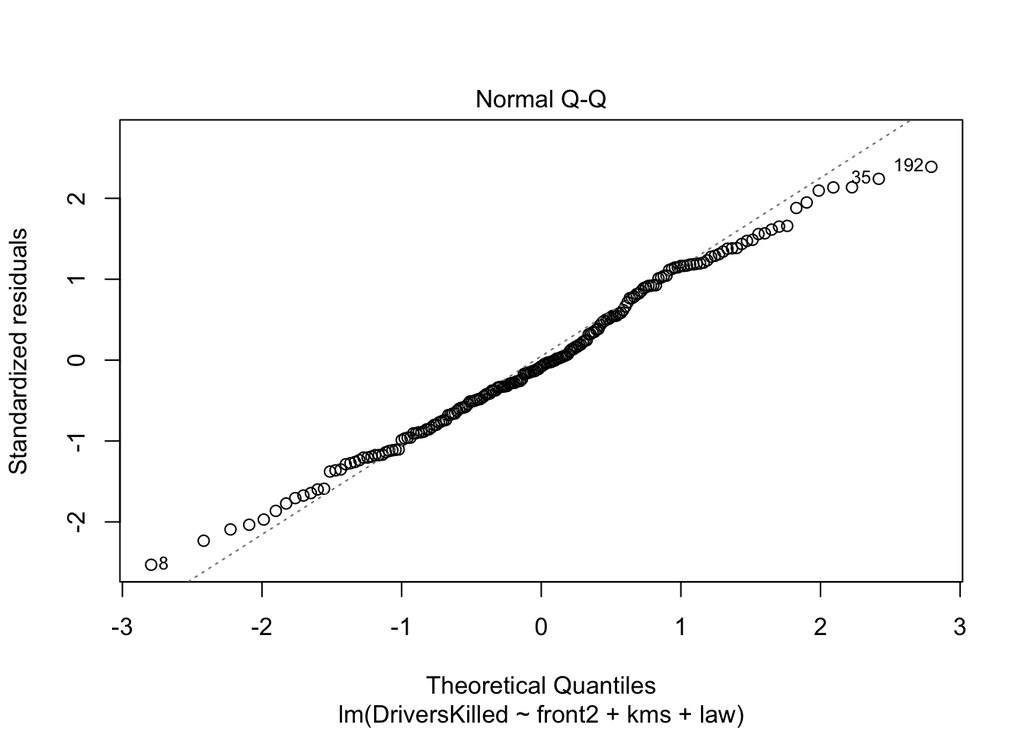

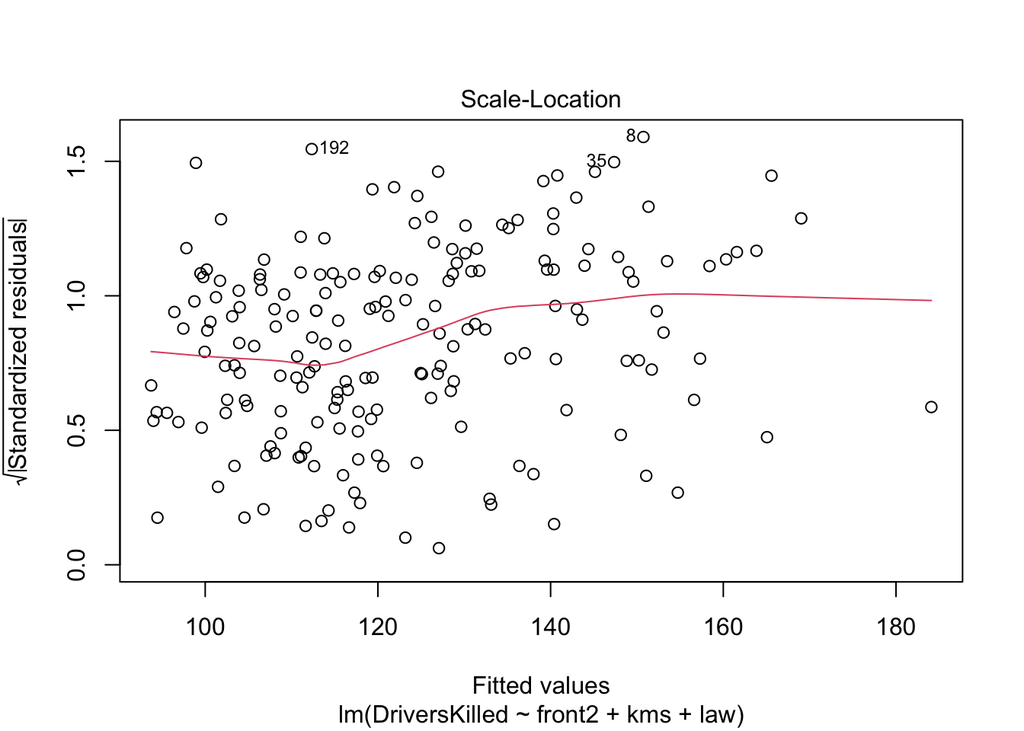

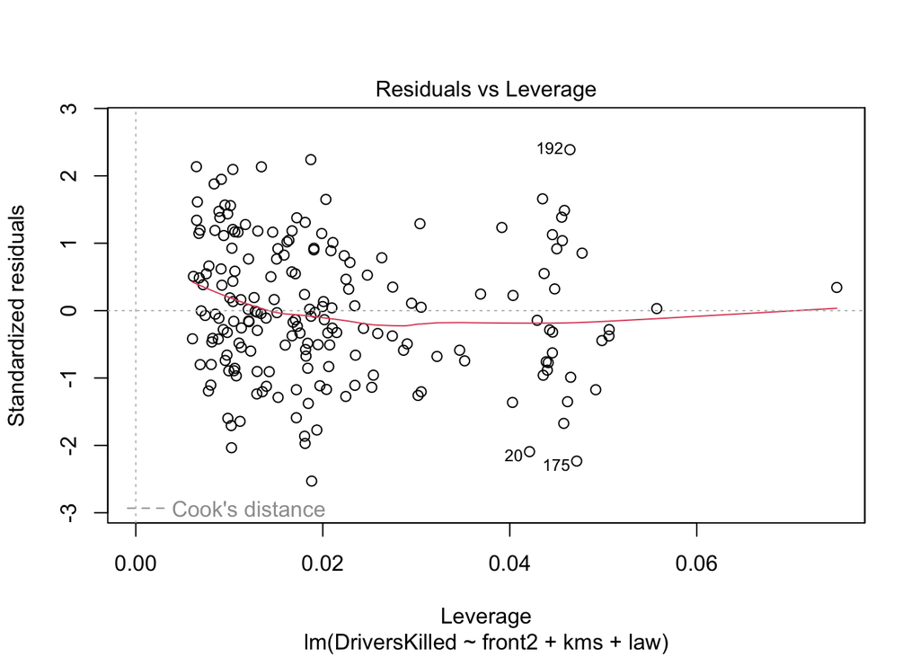

```r
plot(mlm)
```

Our QQ-plot is relatively linear from an eye test, and there does not appear to be any pattern in our plot of residuals vs fitted values as well.

#### Normality of residuals

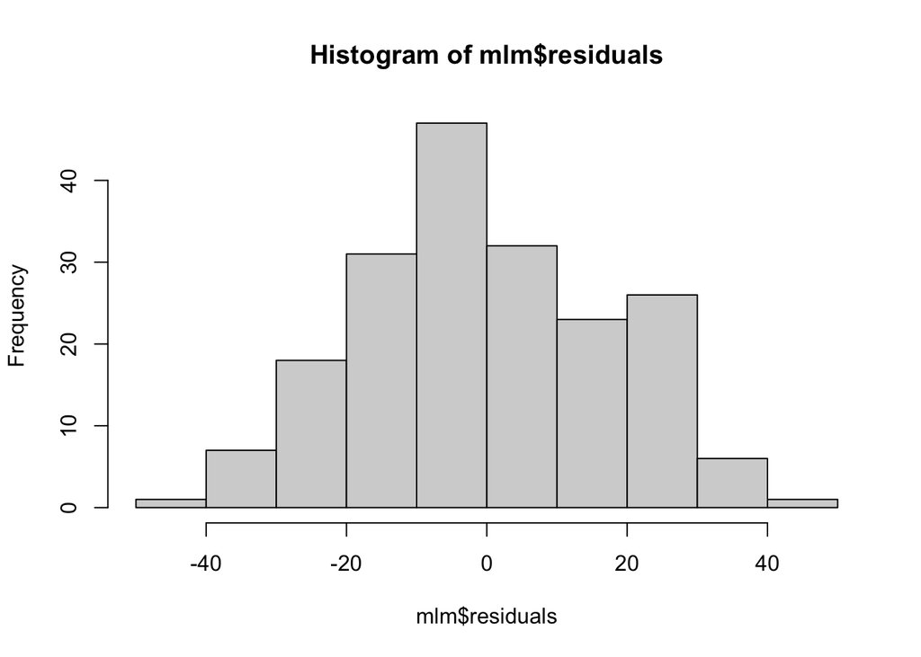

```r
hist(mlm$residuals)
```

```r
shapiro.test(mlm$residuals)
```

```
##
##  Shapiro-Wilk normality test
##
## data:  mlm$residuals
## W = 0.99086, p-value = 0.2639
```

#### Homoscedasticity

From last week’s discussion, we can test the assumption of homoscedasticity (equal variance of residuals for each value of our predictor variables) with a [Breusch-Pagan test](https://www.statology.org/breusch-pagan-test/). We can use the `bptest` in R from the `lmtest` library to test this assumption at a significance level of $\alpha=0.05$

```r
bptest(mlm)
```

```
##
##  studentized Breusch-Pagan test
##
## data:  mlm
## BP = 21.776, df = 3, p-value = 7.261e-05
```